# Risk Factor Analysis

## Outcome Variable

**Outcome Variable:** whz

## Predictor Variables

**Intervention Variable:** mbmi

**Adjustment Set:**

- arm
- W_mage
- meducyrs
- feducyrs
- single
- brthmon
- W_parity
- delta_W_mage
- delta_meducyrs
- delta_feducyrs
- delta_single
- delta_brthmon
- delta_W_parity

## Stratifying Variables

The analysis was stratified on these variable(s):

- agecat
- studyid
- country

## Data Summary

| agecat | studyid | country | mbmi | n_cell | n | outcome_variable |
| --- | --- | --- | --- | --- | --- | --- |
| Birth | JiVitA-3 | BANGLADESH | Normal weight | 10934 | 17935 | whz |
| Birth | JiVitA-3 | BANGLADESH | Underweight | 7001 | 17935 | whz |
| Birth | MAL-ED | BANGLADESH | Normal weight | 183 | 209 | whz |
| Birth | MAL-ED | BANGLADESH | Underweight | 26 | 209 | whz |
| Birth | MAL-ED | BRAZIL | Normal weight | 56 | 61 | whz |
| Birth | MAL-ED | BRAZIL | Underweight | 5 | 61 | whz |
| Birth | MAL-ED | INDIA | Normal weight | 33 | 41 | whz |
| Birth | MAL-ED | INDIA | Underweight | 8 | 41 | whz |
| Birth | MAL-ED | NEPAL | Normal weight | 26 | 26 | whz |
| Birth | MAL-ED | NEPAL | Underweight | 0 | 26 | whz |
| Birth | MAL-ED | PERU | Normal weight | 216 | 221 | whz |
| Birth | MAL-ED | PERU | Underweight | 5 | 221 | whz |
| Birth | MAL-ED | SOUTH AFRICA | Normal weight | 97 | 100 | whz |
| Birth | MAL-ED | SOUTH AFRICA | Underweight | 3 | 100 | whz |
| Birth | MAL-ED | TANZANIA, UNITED REPUBLIC OF | Normal weight | 107 | 113 | whz |
| Birth | MAL-ED | TANZANIA, UNITED REPUBLIC OF | Underweight | 6 | 113 | whz |
| Birth | NIH-Birth | BANGLADESH | Normal weight | 483 | 575 | whz |
| Birth | NIH-Birth | BANGLADESH | Underweight | 92 | 575 | whz |
| Birth | NIH-Crypto | BANGLADESH | Normal weight | 639 | 704 | whz |
| Birth | NIH-Crypto | BANGLADESH | Underweight | 65 | 704 | whz |
| Birth | PROBIT | BELARUS | Normal weight | 13130 | 13651 | whz |
| Birth | PROBIT | BELARUS | Underweight | 521 | 13651 | whz |
| Birth | PROVIDE | BANGLADESH | Normal weight | 411 | 510 | whz |
| Birth | PROVIDE | BANGLADESH | Underweight | 99 | 510 | whz |
| Birth | SAS-CompFeed | INDIA | Normal weight | 735 | 992 | whz |
| Birth | SAS-CompFeed | INDIA | Underweight | 257 | 992 | whz |
| Birth | ZVITAMBO | ZIMBABWE | Normal weight | 8574 | 9030 | whz |
| Birth | ZVITAMBO | ZIMBABWE | Underweight | 456 | 9030 | whz |
| 6 months | JiVitA-3 | BANGLADESH | Normal weight | 10303 | 16733 | whz |
| 6 months | JiVitA-3 | BANGLADESH | Underweight | 6430 | 16733 | whz |

[output cut: 60 more lines]

The following strata were considered:

- agecat: 24 months, studyid: JiVitA-3, country: BANGLADESH
- agecat: 24 months, studyid: LCNI-5, country: MALAWI
- agecat: 24 months, studyid: MAL-ED, country: BANGLADESH
- agecat: 24 months, studyid: MAL-ED, country: BRAZIL
- agecat: 24 months, studyid: MAL-ED, country: INDIA
- agecat: 24 months, studyid: MAL-ED, country: NEPAL
- agecat: 24 months, studyid: MAL-ED, country: PERU
- agecat: 24 months, studyid: MAL-ED, country: SOUTH AFRICA
- agecat: 24 months, studyid: MAL-ED, country: TANZANIA, UNITED REPUBLIC OF
- agecat: 24 months, studyid: NIH-Birth, country: BANGLADESH
- agecat: 24 months, studyid: NIH-Crypto, country: BANGLADESH
- agecat: 24 months, studyid: PROBIT, country: BELARUS
- agecat: 24 months, studyid: PROVIDE, country: BANGLADESH
- agecat: 24 months, studyid: TanzaniaChild2, country: TANZANIA, UNITED REPUBLIC OF
- agecat: 24 months, studyid: ZVITAMBO, country: ZIMBABWE
- agecat: 6 months, studyid: JiVitA-3, country: BANGLADESH
- agecat: 6 months, studyid: LCNI-5, country: MALAWI
- agecat: 6 months, studyid: MAL-ED, country: BANGLADESH
- agecat: 6 months, studyid: MAL-ED, country: BRAZIL
- agecat: 6 months, studyid: MAL-ED, country: INDIA
- agecat: 6 months, studyid: MAL-ED, country: NEPAL
- agecat: 6 months, studyid: MAL-ED, country: PERU
- agecat: 6 months, studyid: MAL-ED, country: SOUTH AFRICA
- agecat: 6 months, studyid: MAL-ED, country: TANZANIA, UNITED REPUBLIC OF
- agecat: 6 months, studyid: NIH-Birth, country: BANGLADESH
- agecat: 6 months, studyid: NIH-Crypto, country: BANGLADESH
- agecat: 6 months, studyid: PROBIT, country: BELARUS
- agecat: 6 months, studyid: PROVIDE, country: BANGLADESH
- agecat: 6 months, studyid: SAS-CompFeed, country: INDIA
- agecat: 6 months, studyid: TanzaniaChild2, country: TANZANIA, UNITED REPUBLIC OF
- agecat: 6 months, studyid: ZVITAMBO, country: ZIMBABWE
- agecat: Birth, studyid: JiVitA-3, country: BANGLADESH
- agecat: Birth, studyid: MAL-ED, country: BANGLADESH
- agecat: Birth, studyid: MAL-ED, country: BRAZIL
- agecat: Birth, studyid: MAL-ED, country: INDIA
- agecat: Birth, studyid: MAL-ED, country: NEPAL
- agecat: Birth, studyid: MAL-ED, country: PERU
- agecat: Birth, studyid: MAL-ED, country: SOUTH AFRICA
- agecat: Birth, studyid: MAL-ED, country: TANZANIA, UNITED REPUBLIC OF
- agecat: Birth, studyid: NIH-Birth, country: BANGLADESH
- agecat: Birth, studyid: NIH-Crypto, country: BANGLADESH
- agecat: Birth, studyid: PROBIT, country: BELARUS
- agecat: Birth, studyid: PROVIDE, country: BANGLADESH
- agecat: Birth, studyid: SAS-CompFeed, country: INDIA
- agecat: Birth, studyid: ZVITAMBO, country: ZIMBABWE

### Dropped Strata

Some strata were dropped due to rare outcomes:

- agecat: Birth, studyid: MAL-ED, country: NEPAL
- agecat: Birth, studyid: MAL-ED, country: SOUTH AFRICA
- agecat: 6 months, studyid: MAL-ED, country: NEPAL
- agecat: 24 months, studyid: MAL-ED, country: NEPAL
- agecat: 24 months, studyid: MAL-ED, country: PERU
- agecat: 24 months, studyid: TanzaniaChild2, country: TANZANIA, UNITED REPUBLIC OF

## Methods Detail

We’re interested in the causal parameters $E[Y_a]$ for all values of $a \in \mathcal{A}$. These parameters represent the mean outcome if, possibly contrary to fact, we intervened to set all units to have $A=a$. Under the randomization and positivity assumptions, these are identified by the statistical parameters $\psi_a=E_W[E_{Y|A,W}(Y|A=a,W)]$. In addition, we’re interested in the mean of $Y$, $E[Y]$ under no intervention (the observed mean). We will estimate these parameters by using SuperLearner to fit the relevant likelihood factors – $E_{Y|A,W}(Y|A=a,W)$ and $p(A=a|W)$, and then updating our likelihood fit using a joint TMLE.

For unadjusted analyses ($W=\{\}$), initial likelihoods were estimated using Lrnr_glm to estimate the simple $E(Y|A)$ and Lrnr_mean to estimate $p(A)$. For adjusted analyses, a small library containing Lrnr_glmnet, Lrnr_xgboost, and Lrnr_mean was used.

Having estimated these parameters, we will then use the delta method to estimate relative risks and attributable risks relative to a prespecified baseline level of $A$.

# Results Detail

## Results Plots

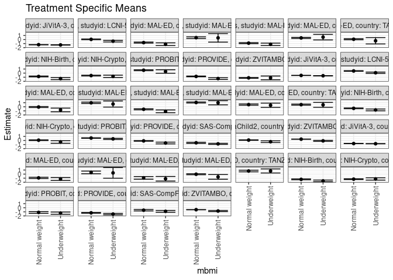

[figure not shown]

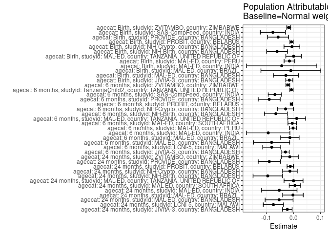

## Results Table

### Parameter: TSM

| agecat | studyid | country | intervention_level | baseline_level | estimate | ci_lower | ci_upper |
| --- | --- | --- | --- | --- | --- | --- | --- |
| Birth | JiVitA-3 | BANGLADESH | Normal weight | NA | -0.7629802 | -0.7863216 | -0.7396389 |
| Birth | JiVitA-3 | BANGLADESH | Underweight | NA | -0.8022244 | -0.8299453 | -0.7745035 |
| Birth | MAL-ED | BANGLADESH | Normal weight | NA | -0.9255935 | -1.0848314 | -0.7663556 |
| Birth | MAL-ED | BANGLADESH | Underweight | NA | -1.1990249 | -1.5494582 | -0.8485916 |
| Birth | MAL-ED | BRAZIL | Normal weight | NA | 0.4114286 | 0.0848121 | 0.7380451 |
| Birth | MAL-ED | BRAZIL | Underweight | NA | 0.2940000 | -1.0086888 | 1.5966888 |
| Birth | MAL-ED | INDIA | Normal weight | NA | -0.9245455 | -1.2487999 | -0.6002910 |
| Birth | MAL-ED | INDIA | Underweight | NA | -1.1462500 | -1.7084286 | -0.5840714 |
| Birth | MAL-ED | PERU | Normal weight | NA | -0.0281944 | -0.1526241 | 0.0962352 |
| Birth | MAL-ED | PERU | Underweight | NA | -0.6820000 | -1.2614133 | -0.1025867 |
| Birth | MAL-ED | TANZANIA, UNITED REPUBLIC OF | Normal weight | NA | 0.7576636 | 0.5539948 | 0.9613323 |
| Birth | MAL-ED | TANZANIA, UNITED REPUBLIC OF | Underweight | NA | 0.7700000 | 0.2691531 | 1.2708469 |
| Birth | NIH-Birth | BANGLADESH | Normal weight | NA | -1.2897297 | -1.3947054 | -1.1847540 |
| Birth | NIH-Birth | BANGLADESH | Underweight | NA | -1.6633768 | -1.8733234 | -1.4534301 |
| Birth | NIH-Crypto | BANGLADESH | Normal weight | NA | -1.2378858 | -1.3260362 | -1.1497355 |
| Birth | NIH-Crypto | BANGLADESH | Underweight | NA | -1.1837478 | -1.4648306 | -0.9026650 |
| Birth | PROBIT | BELARUS | Normal weight | NA | -1.1404080 | -1.3509654 | -0.9298506 |
| Birth | PROBIT | BELARUS | Underweight | NA | -1.3240868 | -1.6011215 | -1.0470521 |
| Birth | PROVIDE | BANGLADESH | Normal weight | NA | -1.2496100 | -1.3363372 | -1.1628828 |
| Birth | PROVIDE | BANGLADESH | Underweight | NA | -1.5561004 | -1.7385256 | -1.3736751 |
| Birth | SAS-CompFeed | INDIA | Normal weight | NA | -0.5993547 | -0.7761424 | -0.4225670 |
| Birth | SAS-CompFeed | INDIA | Underweight | NA | -0.8766507 | -1.1045877 | -0.6487138 |
| Birth | ZVITAMBO | ZIMBABWE | Normal weight | NA | -0.4732225 | -0.5049678 | -0.4414772 |
| Birth | ZVITAMBO | ZIMBABWE | Underweight | NA | -0.7997365 | -0.9393393 | -0.6601338 |
| 6 months | JiVitA-3 | BANGLADESH | Normal weight | NA | -0.5638627 | -0.5867827 | -0.5409427 |
| 6 months | JiVitA-3 | BANGLADESH | Underweight | NA | -0.6388953 | -0.6699920 | -0.6077987 |
| 6 months | LCNI-5 | MALAWI | Normal weight | NA | 0.5316998 | 0.4534856 | 0.6099139 |
| 6 months | LCNI-5 | MALAWI | Underweight | NA | 0.0954228 | -0.0656678 | 0.2565133 |
| 6 months | MAL-ED | BANGLADESH | Normal weight | NA | -0.0571128 | -0.1856320 | 0.0714065 |
| 6 months | MAL-ED | BANGLADESH | Underweight | NA | -0.7685690 | -1.2191142 | -0.3180239 |
| 6 months | MAL-ED | BRAZIL | Normal weight | NA | 0.9779606 | 0.8096461 | 1.1462751 |
| 6 months | MAL-ED | BRAZIL | Underweight | NA | 0.6750000 | -0.0698801 | 1.4198801 |
| 6 months | MAL-ED | INDIA | Normal weight | NA | -0.6104364 | -0.7425062 | -0.4783666 |
| 6 months | MAL-ED | INDIA | Underweight | NA | -1.1194784 | -1.4661125 | -0.7728443 |
| 6 months | MAL-ED | PERU | Normal weight | NA | 1.0561298 | 0.9317231 | 1.1805366 |
| 6 months | MAL-ED | PERU | Underweight | NA | 0.9870000 | 0.4781587 | 1.4958413 |
| 6 months | MAL-ED | SOUTH AFRICA | Normal weight | NA | 0.5335468 | 0.3758513 | 0.6912424 |
| 6 months | MAL-ED | SOUTH AFRICA | Underweight | NA | 0.3771429 | -0.1498294 | 0.9041151 |
| 6 months | MAL-ED | TANZANIA, UNITED REPUBLIC OF | Normal weight | NA | 0.5241571 | 0.3888471 | 0.6594671 |
| 6 months | MAL-ED | TANZANIA, UNITED REPUBLIC OF | Underweight | NA | 0.4771457 | -0.1251829 | 1.0794743 |
| 6 months | NIH-Birth | BANGLADESH | Normal weight | NA | -0.3825146 | -0.4814008 | -0.2836285 |
| 6 months | NIH-Birth | BANGLADESH | Underweight | NA | -0.7685854 | -0.9876310 | -0.5495398 |
| 6 months | NIH-Crypto | BANGLADESH | Normal weight | NA | 0.0586381 | -0.0239219 | 0.1411982 |
| 6 months | NIH-Crypto | BANGLADESH | Underweight | NA | -0.3815821 | -0.6929144 | -0.0702497 |
| 6 months | PROBIT | BELARUS | Normal weight | NA | 0.5861343 | 0.5280254 | 0.6442432 |
| 6 months | PROBIT | BELARUS | Underweight | NA | 0.3886683 | 0.2523586 | 0.5249780 |
| 6 months | PROVIDE | BANGLADESH | Normal weight | NA | -0.1093440 | -0.1987284 | -0.0199596 |
| 6 months | PROVIDE | BANGLADESH | Underweight | NA | -0.6247985 | -0.8394266 | -0.4101705 |
| 6 months | SAS-CompFeed | INDIA | Normal weight | NA | -0.5743315 | -0.7120177 | -0.4366453 |
| 6 months | SAS-CompFeed | INDIA | Underweight | NA | -0.8362207 | -0.9702569 | -0.7021845 |
| 6 months | TanzaniaChild2 | TANZANIA, UNITED REPUBLIC OF | Normal weight | NA | 0.0846287 | 0.0302335 | 0.1390239 |
| 6 months | TanzaniaChild2 | TANZANIA, UNITED REPUBLIC OF | Underweight | NA | -0.3099541 | -0.5233783 | -0.0965300 |
| 6 months | ZVITAMBO | ZIMBABWE | Normal weight | NA | 0.3154412 | 0.2873046 | 0.3435778 |
| 6 months | ZVITAMBO | ZIMBABWE | Underweight | NA | -0.1003452 | -0.2309787 | 0.0302882 |
| 24 months | JiVitA-3 | BANGLADESH | Normal weight | NA | -1.2745444 | -1.3038033 | -1.2452855 |
| 24 months | JiVitA-3 | BANGLADESH | Underweight | NA | -1.3349706 | -1.3715666 | -1.2983747 |
| 24 months | LCNI-5 | MALAWI | Normal weight | NA | 0.0269221 | -0.0619656 | 0.1158098 |
| 24 months | LCNI-5 | MALAWI | Underweight | NA | -0.4185937 | -0.6103829 | -0.2268045 |
| 24 months | MAL-ED | BANGLADESH | Normal weight | NA | -0.7664441 | -0.8968988 | -0.6359894 |
| 24 months | MAL-ED | BANGLADESH | Underweight | NA | -1.1510822 | -1.4805488 | -0.8216155 |
| 24 months | MAL-ED | BRAZIL | Normal weight | NA | 0.4461317 | 0.2381826 | 0.6540808 |
| 24 months | MAL-ED | BRAZIL | Underweight | NA | 0.3966667 | -0.6451983 | 1.4385316 |
| 24 months | MAL-ED | INDIA | Normal weight | NA | -0.8997476 | -1.0237331 | -0.7757621 |
| 24 months | MAL-ED | INDIA | Underweight | NA | -1.1775476 | -1.4672681 | -0.8878271 |
| 24 months | MAL-ED | SOUTH AFRICA | Normal weight | NA | 0.3861417 | 0.2630585 | 0.5092249 |
| 24 months | MAL-ED | SOUTH AFRICA | Underweight | NA | 0.5700000 | -0.1123856 | 1.2523856 |
| 24 months | MAL-ED | TANZANIA, UNITED REPUBLIC OF | Normal weight | NA | 0.0543956 | -0.0730055 | 0.1817968 |
| 24 months | MAL-ED | TANZANIA, UNITED REPUBLIC OF | Underweight | NA | -0.3195659 | -1.0963456 | 0.4572138 |
| 24 months | NIH-Birth | BANGLADESH | Normal weight | NA | -0.8167708 | -0.9202488 | -0.7132928 |
| 24 months | NIH-Birth | BANGLADESH | Underweight | NA | -1.3388234 | -1.5960493 | -1.0815975 |
| 24 months | NIH-Crypto | BANGLADESH | Normal weight | NA | -0.5974558 | -0.6968936 | -0.4980180 |
| 24 months | NIH-Crypto | BANGLADESH | Underweight | NA | -0.7805190 | -1.0709736 | -0.4900643 |
| 24 months | PROBIT | BELARUS | Normal weight | NA | 0.7104599 | 0.5980914 | 0.8228284 |
| 24 months | PROBIT | BELARUS | Underweight | NA | 0.3988495 | -0.0266546 | 0.8243536 |
| 24 months | PROVIDE | BANGLADESH | Normal weight | NA | -0.8025156 | -0.8918940 | -0.7131371 |
| 24 months | PROVIDE | BANGLADESH | Underweight | NA | -1.3307725 | -1.5475641 | -1.1139809 |
| 24 months | ZVITAMBO | ZIMBABWE | Normal weight | NA | -1.1584918 | -1.2717950 | -1.0451887 |
| 24 months | ZVITAMBO | ZIMBABWE | Underweight | NA | -1.1710308 | -1.6322838 | -0.7097779 |

### Parameter: E(Y)

| agecat | studyid | country | intervention_level | baseline_level | estimate | ci_lower | ci_upper |
| --- | --- | --- | --- | --- | --- | --- | --- |
| Birth | JiVitA-3 | BANGLADESH | NA | NA | -0.7781583 | -0.7971779 | -0.7591388 |
| Birth | MAL-ED | BANGLADESH | NA | NA | -0.9533493 | -1.0984355 | -0.8082631 |
| Birth | MAL-ED | BRAZIL | NA | NA | 0.4018033 | 0.0834093 | 0.7201973 |
| Birth | MAL-ED | INDIA | NA | NA | -0.9678049 | -1.2522118 | -0.6833979 |
| Birth | MAL-ED | PERU | NA | NA | -0.0429864 | -0.1658406 | 0.0798678 |
| Birth | MAL-ED | TANZANIA, UNITED REPUBLIC OF | NA | NA | 0.7583186 | 0.5636385 | 0.9529987 |
| Birth | NIH-Birth | BANGLADESH | NA | NA | -1.3499217 | -1.4444634 | -1.2553801 |
| Birth | NIH-Crypto | BANGLADESH | NA | NA | -1.2434730 | -1.3276901 | -1.1592559 |
| Birth | PROBIT | BELARUS | NA | NA | -1.1472584 | -1.3582745 | -0.9362424 |
| Birth | PROVIDE | BANGLADESH | NA | NA | -1.3060980 | -1.3843247 | -1.2278714 |
| Birth | SAS-CompFeed | INDIA | NA | NA | -0.6752218 | -0.8548888 | -0.4955547 |
| Birth | ZVITAMBO | ZIMBABWE | NA | NA | -0.4905338 | -0.5214551 | -0.4596125 |
| 6 months | JiVitA-3 | BANGLADESH | NA | NA | -0.5931545 | -0.6127055 | -0.5736036 |
| 6 months | LCNI-5 | MALAWI | NA | NA | 0.4515550 | 0.3802638 | 0.5228463 |
| 6 months | MAL-ED | BANGLADESH | NA | NA | -0.1376763 | -0.2664642 | -0.0088885 |
| 6 months | MAL-ED | BRAZIL | NA | NA | 0.9648518 | 0.8004118 | 1.1292917 |
| 6 months | MAL-ED | INDIA | NA | NA | -0.7034149 | -0.8300527 | -0.5767771 |
| 6 months | MAL-ED | PERU | NA | NA | 1.0548591 | 0.9328922 | 1.1768259 |
| 6 months | MAL-ED | SOUTH AFRICA | NA | NA | 0.5291499 | 0.3751396 | 0.6831602 |
| 6 months | MAL-ED | TANZANIA, UNITED REPUBLIC OF | NA | NA | 0.5362213 | 0.4049390 | 0.6675036 |
| 6 months | NIH-Birth | BANGLADESH | NA | NA | -0.4474038 | -0.5378167 | -0.3569909 |
| 6 months | NIH-Crypto | BANGLADESH | NA | NA | 0.0297622 | -0.0491685 | 0.1086930 |
| 6 months | PROBIT | BELARUS | NA | NA | 0.5785149 | 0.5197782 | 0.6372516 |
| 6 months | PROVIDE | BANGLADESH | NA | NA | -0.1987071 | -0.2815473 | -0.1158669 |
| 6 months | SAS-CompFeed | INDIA | NA | NA | -0.6426305 | -0.7702214 | -0.5150396 |
| 6 months | TanzaniaChild2 | TANZANIA, UNITED REPUBLIC OF | NA | NA | 0.0775172 | 0.0241750 | 0.1308595 |
| 6 months | ZVITAMBO | ZIMBABWE | NA | NA | 0.2948332 | 0.2672524 | 0.3224139 |
| 24 months | JiVitA-3 | BANGLADESH | NA | NA | -1.2970642 | -1.3203662 | -1.2737621 |
| 24 months | LCNI-5 | MALAWI | NA | NA | -0.0468717 | -0.1290135 | 0.0352701 |
| 24 months | MAL-ED | BANGLADESH | NA | NA | -0.8192925 | -0.9412667 | -0.6973182 |
| 24 months | MAL-ED | BRAZIL | NA | NA | 0.4443651 | 0.2404149 | 0.6483153 |
| 24 months | MAL-ED | INDIA | NA | NA | -0.9519248 | -1.0678488 | -0.8360007 |
| 24 months | MAL-ED | SOUTH AFRICA | NA | NA | 0.3916417 | 0.2704414 | 0.5128421 |
| 24 months | MAL-ED | TANZANIA, UNITED REPUBLIC OF | NA | NA | 0.0547975 | -0.0703378 | 0.1799328 |
| 24 months | NIH-Birth | BANGLADESH | NA | NA | -0.9115790 | -1.0095022 | -0.8136559 |
| 24 months | NIH-Crypto | BANGLADESH | NA | NA | -0.6103502 | -0.7050157 | -0.5156847 |
| 24 months | PROBIT | BELARUS | NA | NA | 0.6991214 | 0.5821715 | 0.8160713 |
| 24 months | PROVIDE | BANGLADESH | NA | NA | -0.8914360 | -0.9741797 | -0.8086923 |
| 24 months | ZVITAMBO | ZIMBABWE | NA | NA | -1.1718579 | -1.2809898 | -1.0627260 |

### Parameter: ATE

| agecat | studyid | country | intervention_level | baseline_level | estimate | ci_lower | ci_upper |
| --- | --- | --- | --- | --- | --- | --- | --- |
| Birth | JiVitA-3 | BANGLADESH | Normal weight | Normal weight | 0.0000000 | 0.0000000 | 0.0000000 |
| Birth | JiVitA-3 | BANGLADESH | Underweight | Normal weight | -0.0392441 | -0.0726791 | -0.0058092 |
| Birth | MAL-ED | BANGLADESH | Normal weight | Normal weight | 0.0000000 | 0.0000000 | 0.0000000 |
| Birth | MAL-ED | BANGLADESH | Underweight | Normal weight | -0.2734315 | -0.6589554 | 0.1120925 |
| Birth | MAL-ED | BRAZIL | Normal weight | Normal weight | 0.0000000 | 0.0000000 | 0.0000000 |
| Birth | MAL-ED | BRAZIL | Underweight | Normal weight | -0.1174286 | -1.4604388 | 1.2255816 |
| Birth | MAL-ED | INDIA | Normal weight | Normal weight | 0.0000000 | 0.0000000 | 0.0000000 |
| Birth | MAL-ED | INDIA | Underweight | Normal weight | -0.2217045 | -0.8706928 | 0.4272837 |
| Birth | MAL-ED | PERU | Normal weight | Normal weight | 0.0000000 | 0.0000000 | 0.0000000 |
| Birth | MAL-ED | PERU | Underweight | Normal weight | -0.6538056 | -1.2464290 | -0.0611821 |
| Birth | MAL-ED | TANZANIA, UNITED REPUBLIC OF | Normal weight | Normal weight | 0.0000000 | 0.0000000 | 0.0000000 |
| Birth | MAL-ED | TANZANIA, UNITED REPUBLIC OF | Underweight | Normal weight | 0.0123364 | -0.5283378 | 0.5530107 |
| Birth | NIH-Birth | BANGLADESH | Normal weight | Normal weight | 0.0000000 | 0.0000000 | 0.0000000 |
| Birth | NIH-Birth | BANGLADESH | Underweight | Normal weight | -0.3736470 | -0.6085118 | -0.1387823 |
| Birth | NIH-Crypto | BANGLADESH | Normal weight | Normal weight | 0.0000000 | 0.0000000 | 0.0000000 |
| Birth | NIH-Crypto | BANGLADESH | Underweight | Normal weight | 0.0541380 | -0.2406173 | 0.3488934 |
| Birth | PROBIT | BELARUS | Normal weight | Normal weight | 0.0000000 | 0.0000000 | 0.0000000 |
| Birth | PROBIT | BELARUS | Underweight | Normal weight | -0.1836788 | -0.3468235 | -0.0205341 |
| Birth | PROVIDE | BANGLADESH | Normal weight | Normal weight | 0.0000000 | 0.0000000 | 0.0000000 |
| Birth | PROVIDE | BANGLADESH | Underweight | Normal weight | -0.3064903 | -0.5085156 | -0.1044651 |
| Birth | SAS-CompFeed | INDIA | Normal weight | Normal weight | 0.0000000 | 0.0000000 | 0.0000000 |
| Birth | SAS-CompFeed | INDIA | Underweight | Normal weight | -0.2772960 | -0.4591349 | -0.0954572 |
| Birth | ZVITAMBO | ZIMBABWE | Normal weight | Normal weight | 0.0000000 | 0.0000000 | 0.0000000 |
| Birth | ZVITAMBO | ZIMBABWE | Underweight | Normal weight | -0.3265141 | -0.4696521 | -0.1833760 |
| 6 months | JiVitA-3 | BANGLADESH | Normal weight | Normal weight | 0.0000000 | 0.0000000 | 0.0000000 |
| 6 months | JiVitA-3 | BANGLADESH | Underweight | Normal weight | -0.0750326 | -0.1111991 | -0.0388662 |
| 6 months | LCNI-5 | MALAWI | Normal weight | Normal weight | 0.0000000 | 0.0000000 | 0.0000000 |
| 6 months | LCNI-5 | MALAWI | Underweight | Normal weight | -0.4362770 | -0.6154709 | -0.2570830 |
| 6 months | MAL-ED | BANGLADESH | Normal weight | Normal weight | 0.0000000 | 0.0000000 | 0.0000000 |
| 6 months | MAL-ED | BANGLADESH | Underweight | Normal weight | -0.7114562 | -1.1800867 | -0.2428257 |
| 6 months | MAL-ED | BRAZIL | Normal weight | Normal weight | 0.0000000 | 0.0000000 | 0.0000000 |
| 6 months | MAL-ED | BRAZIL | Underweight | Normal weight | -0.3029606 | -1.0666204 | 0.4606991 |
| 6 months | MAL-ED | INDIA | Normal weight | Normal weight | 0.0000000 | 0.0000000 | 0.0000000 |
| 6 months | MAL-ED | INDIA | Underweight | Normal weight | -0.5090420 | -0.8818430 | -0.1362410 |
| 6 months | MAL-ED | PERU | Normal weight | Normal weight | 0.0000000 | 0.0000000 | 0.0000000 |
| 6 months | MAL-ED | PERU | Underweight | Normal weight | -0.0691298 | -0.5929586 | 0.4546989 |
| 6 months | MAL-ED | SOUTH AFRICA | Normal weight | Normal weight | 0.0000000 | 0.0000000 | 0.0000000 |
| 6 months | MAL-ED | SOUTH AFRICA | Underweight | Normal weight | -0.1564040 | -0.7064654 | 0.3936575 |
| 6 months | MAL-ED | TANZANIA, UNITED REPUBLIC OF | Normal weight | Normal weight | 0.0000000 | 0.0000000 | 0.0000000 |
| 6 months | MAL-ED | TANZANIA, UNITED REPUBLIC OF | Underweight | Normal weight | -0.0470114 | -0.6660062 | 0.5719834 |
| 6 months | NIH-Birth | BANGLADESH | Normal weight | Normal weight | 0.0000000 | 0.0000000 | 0.0000000 |
| 6 months | NIH-Birth | BANGLADESH | Underweight | Normal weight | -0.3860708 | -0.6267136 | -0.1454280 |
| 6 months | NIH-Crypto | BANGLADESH | Normal weight | Normal weight | 0.0000000 | 0.0000000 | 0.0000000 |
| 6 months | NIH-Crypto | BANGLADESH | Underweight | Normal weight | -0.4402202 | -0.7622034 | -0.1182370 |
| 6 months | PROBIT | BELARUS | Normal weight | Normal weight | 0.0000000 | 0.0000000 | 0.0000000 |
| 6 months | PROBIT | BELARUS | Underweight | Normal weight | -0.1974660 | -0.3172696 | -0.0776623 |
| 6 months | PROVIDE | BANGLADESH | Normal weight | Normal weight | 0.0000000 | 0.0000000 | 0.0000000 |
| 6 months | PROVIDE | BANGLADESH | Underweight | Normal weight | -0.5154546 | -0.7479701 | -0.2829390 |
| 6 months | SAS-CompFeed | INDIA | Normal weight | Normal weight | 0.0000000 | 0.0000000 | 0.0000000 |
| 6 months | SAS-CompFeed | INDIA | Underweight | Normal weight | -0.2618892 | -0.3644431 | -0.1593353 |
| 6 months | TanzaniaChild2 | TANZANIA, UNITED REPUBLIC OF | Normal weight | Normal weight | 0.0000000 | 0.0000000 | 0.0000000 |
| 6 months | TanzaniaChild2 | TANZANIA, UNITED REPUBLIC OF | Underweight | Normal weight | -0.3945828 | -0.6144005 | -0.1747652 |
| 6 months | ZVITAMBO | ZIMBABWE | Normal weight | Normal weight | 0.0000000 | 0.0000000 | 0.0000000 |
| 6 months | ZVITAMBO | ZIMBABWE | Underweight | Normal weight | -0.4157864 | -0.5493480 | -0.2822249 |
| 24 months | JiVitA-3 | BANGLADESH | Normal weight | Normal weight | 0.0000000 | 0.0000000 | 0.0000000 |
| 24 months | JiVitA-3 | BANGLADESH | Underweight | Normal weight | -0.0604262 | -0.1064884 | -0.0143640 |
| 24 months | LCNI-5 | MALAWI | Normal weight | Normal weight | 0.0000000 | 0.0000000 | 0.0000000 |
| 24 months | LCNI-5 | MALAWI | Underweight | Normal weight | -0.4455158 | -0.6557028 | -0.2353287 |
| 24 months | MAL-ED | BANGLADESH | Normal weight | Normal weight | 0.0000000 | 0.0000000 | 0.0000000 |
| 24 months | MAL-ED | BANGLADESH | Underweight | Normal weight | -0.3846381 | -0.7392813 | -0.0299948 |
| 24 months | MAL-ED | BRAZIL | Normal weight | Normal weight | 0.0000000 | 0.0000000 | 0.0000000 |
| 24 months | MAL-ED | BRAZIL | Underweight | Normal weight | -0.0494650 | -1.1118799 | 1.0129498 |
| 24 months | MAL-ED | INDIA | Normal weight | Normal weight | 0.0000000 | 0.0000000 | 0.0000000 |
| 24 months | MAL-ED | INDIA | Underweight | Normal weight | -0.2778000 | -0.5917896 | 0.0361896 |
| 24 months | MAL-ED | SOUTH AFRICA | Normal weight | Normal weight | 0.0000000 | 0.0000000 | 0.0000000 |
| 24 months | MAL-ED | SOUTH AFRICA | Underweight | Normal weight | 0.1838583 | -0.5095388 | 0.8772554 |
| 24 months | MAL-ED | TANZANIA, UNITED REPUBLIC OF | Normal weight | Normal weight | 0.0000000 | 0.0000000 | 0.0000000 |
| 24 months | MAL-ED | TANZANIA, UNITED REPUBLIC OF | Underweight | Normal weight | -0.3739616 | -1.1627327 | 0.4148095 |
| 24 months | NIH-Birth | BANGLADESH | Normal weight | Normal weight | 0.0000000 | 0.0000000 | 0.0000000 |
| 24 months | NIH-Birth | BANGLADESH | Underweight | Normal weight | -0.5220526 | -0.7994512 | -0.2446541 |
| 24 months | NIH-Crypto | BANGLADESH | Normal weight | Normal weight | 0.0000000 | 0.0000000 | 0.0000000 |
| 24 months | NIH-Crypto | BANGLADESH | Underweight | Normal weight | -0.1830631 | -0.4902697 | 0.1241434 |
| 24 months | PROBIT | BELARUS | Normal weight | Normal weight | 0.0000000 | 0.0000000 | 0.0000000 |
| 24 months | PROBIT | BELARUS | Underweight | Normal weight | -0.3116104 | -0.6910781 | 0.0678573 |
| 24 months | PROVIDE | BANGLADESH | Normal weight | Normal weight | 0.0000000 | 0.0000000 | 0.0000000 |
| 24 months | PROVIDE | BANGLADESH | Underweight | Normal weight | -0.5282570 | -0.7626424 | -0.2938716 |
| 24 months | ZVITAMBO | ZIMBABWE | Normal weight | Normal weight | 0.0000000 | 0.0000000 | 0.0000000 |
| 24 months | ZVITAMBO | ZIMBABWE | Underweight | Normal weight | -0.0125390 | -0.4873552 | 0.4622771 |

### Parameter: PAR

| agecat | studyid | country | intervention_level | baseline_level | estimate | ci_lower | ci_upper |
| --- | --- | --- | --- | --- | --- | --- | --- |
| Birth | JiVitA-3 | BANGLADESH | Normal weight | NA | -0.0151781 | -0.0282110 | -0.0021452 |
| Birth | MAL-ED | BANGLADESH | Normal weight | NA | -0.0277558 | -0.0740166 | 0.0185050 |
| Birth | MAL-ED | BRAZIL | Normal weight | NA | -0.0096253 | -0.1200094 | 0.1007588 |
| Birth | MAL-ED | INDIA | Normal weight | NA | -0.0432594 | -0.1727854 | 0.0862665 |
| Birth | MAL-ED | PERU | Normal weight | NA | -0.0147920 | -0.0344019 | 0.0048180 |
| Birth | MAL-ED | TANZANIA, UNITED REPUBLIC OF | Normal weight | NA | 0.0006550 | -0.0280579 | 0.0293680 |
| Birth | NIH-Birth | BANGLADESH | Normal weight | NA | -0.0601920 | -0.0986462 | -0.0217378 |
| Birth | NIH-Crypto | BANGLADESH | Normal weight | NA | -0.0055872 | -0.0348006 | 0.0236262 |
| Birth | PROBIT | BELARUS | Normal weight | NA | -0.0068504 | -0.0129598 | -0.0007410 |
| Birth | PROVIDE | BANGLADESH | Normal weight | NA | -0.0564880 | -0.0952036 | -0.0177725 |
| Birth | SAS-CompFeed | INDIA | Normal weight | NA | -0.0758670 | -0.1220849 | -0.0296492 |
| Birth | ZVITAMBO | ZIMBABWE | Normal weight | NA | -0.0173113 | -0.0244369 | -0.0101857 |
| 6 months | JiVitA-3 | BANGLADESH | Normal weight | NA | -0.0292918 | -0.0430844 | -0.0154992 |
| 6 months | LCNI-5 | MALAWI | Normal weight | NA | -0.0801447 | -0.1133121 | -0.0469773 |
| 6 months | MAL-ED | BANGLADESH | Normal weight | NA | -0.0805636 | -0.1473274 | -0.0137997 |
| 6 months | MAL-ED | BRAZIL | Normal weight | NA | -0.0131089 | -0.0472021 | 0.0209844 |
| 6 months | MAL-ED | INDIA | Normal weight | NA | -0.0929785 | -0.1729951 | -0.0129619 |
| 6 months | MAL-ED | PERU | Normal weight | NA | -0.0012708 | -0.0144131 | 0.0118715 |
| 6 months | MAL-ED | SOUTH AFRICA | Normal weight | NA | -0.0043969 | -0.0201917 | 0.0113979 |
| 6 months | MAL-ED | TANZANIA, UNITED REPUBLIC OF | Normal weight | NA | 0.0120642 | -0.0206997 | 0.0448282 |
| 6 months | NIH-Birth | BANGLADESH | Normal weight | NA | -0.0648892 | -0.1072479 | -0.0225304 |
| 6 months | NIH-Crypto | BANGLADESH | Normal weight | NA | -0.0288759 | -0.0583100 | 0.0005582 |
| 6 months | PROBIT | BELARUS | Normal weight | NA | -0.0076194 | -0.0119488 | -0.0032899 |
| 6 months | PROVIDE | BANGLADESH | Normal weight | NA | -0.0893631 | -0.1299593 | -0.0487669 |
| 6 months | SAS-CompFeed | INDIA | Normal weight | NA | -0.0682990 | -0.0930723 | -0.0435257 |
| 6 months | TanzaniaChild2 | TANZANIA, UNITED REPUBLIC OF | Normal weight | NA | -0.0071115 | -0.0132250 | -0.0009979 |
| 6 months | ZVITAMBO | ZIMBABWE | Normal weight | NA | -0.0206080 | -0.0276866 | -0.0135295 |
| 24 months | JiVitA-3 | BANGLADESH | Normal weight | NA | -0.0225198 | -0.0402497 | -0.0047898 |
| 24 months | LCNI-5 | MALAWI | Normal weight | NA | -0.0737937 | -0.1112913 | -0.0362961 |
| 24 months | MAL-ED | BANGLADESH | Normal weight | NA | -0.0528484 | -0.1044079 | -0.0012888 |
| 24 months | MAL-ED | BRAZIL | Normal weight | NA | -0.0017666 | -0.0397355 | 0.0362023 |
| 24 months | MAL-ED | INDIA | Normal weight | NA | -0.0521772 | -0.1176106 | 0.0132562 |
| 24 months | MAL-ED | SOUTH AFRICA | Normal weight | NA | 0.0055000 | -0.0156289 | 0.0266289 |
| 24 months | MAL-ED | TANZANIA, UNITED REPUBLIC OF | Normal weight | NA | 0.0004019 | -0.0346197 | 0.0354235 |
| 24 months | NIH-Birth | BANGLADESH | Normal weight | NA | -0.0948083 | -0.1489572 | -0.0406593 |
| 24 months | NIH-Crypto | BANGLADESH | Normal weight | NA | -0.0128944 | -0.0399039 | 0.0141151 |
| 24 months | PROBIT | BELARUS | Normal weight | NA | -0.0113385 | -0.0234999 | 0.0008229 |
| 24 months | PROVIDE | BANGLADESH | Normal weight | NA | -0.0889204 | -0.1299746 | -0.0478663 |
| 24 months | ZVITAMBO | ZIMBABWE | Normal weight | NA | -0.0133661 | -0.0447266 | 0.0179944 |